# From analysis to communication with Quarto

Professional documents from RStudio

Patrick Bolger

# Today’s agenda

## Two short halves

### First 30 minutes: Introduction

- Communication tools
- Markdown essentials
- *Quarto* file structure

### Final 30 minutes: Practice

- Choose a document
- Prompt MS Copilot
- Save as `.qmd`
- Render, inspect, refine

# Communication tools

## Visual editors

### Examples

- *Word*
- *PowerPoint*
- *Google Docs*
- *Canva*

### Downsides

- proprietary
- local formatting

### Upsides

- *What you see is what you get*
  - WYSIWYG
- easy to learn

## Mark-up systems

### Examples

- HTML
- *LaTeX*
- *Typst*

### Upsides

- plain text
- open-source
- easy to share

### Downside

- “steep” learning curve<sup>1</sup>
[^1]: Technically, a shallow learning curve

## Markdown

### Origin (2004)

- [John Gruber](https://en.wikipedia.org/wiki/John_Gruber) & [Aaron Swartz](https://en.wikipedia.org/wiki/Aaron_Swartz)<sup>1</sup>
- felt raw html was onerous
- Hence, Mark*down*
  - *up* = complex
  - *down* = simple
- converts natively to HTML
  - its raison d’être

### Upsides

- plain text
- easy to…
  - read
  - learn
  - share
  - render

### Downsides

- By itself: Few bells and whistles
  - But *R Markdown* and *Quarto* add many back in
- not fully WYSIWYG
  - but 90% of the way there
  - a small price to pay (in my own view)
[^2]: RIP

## Scientific publishing systems

Combine prose, code, and output specifications

### For today (part of *RStudio*)

- *R Markdown*
- *Quarto*

### Others

- *Jupyter Notebooks*
- *Jupyter Books*
- *MyST Markdown*

**Important**

These systems can export plain text into various formats, like documents (*Word*, pdf), slide decks (*PowerPoint*, *slidy*, *beamer*, *revealjs*), websites, online books, e-books, data dashboards, etc.

## *R Markdown* and *Quarto*

### *R Markdown*

- Introduced reproducible documents to many *R* users
- Uses `.Rmd` source files
- Inseparable integration with *R*
  - you can’t render without *R* installed
- Still widely used

### *Quarto*

- Newer, more language-neutral publishing system
- Uses `.qmd` source files
- Works with *R*, *Python*, *Julia* and *Observable JS*
  - hence *Quarto* (the four languages)
- Standalone
  - no *a priori* requirement to install *R*

## A typical workflow for *Quarto* and *R Markdown*

1. Create a *Quarto* or *R Markdown* file in *RStudio*
2. Add
   1. Required
      1. YAML header
   2. And one, or the other, or both of:
      1. *Markdown*
      2. code (or *Python*, etc.)
3. Select **Render**
4. The chosen output is rendered
5. If necessary, edit the source, then render again

## File-conversion processes

- *Markdown* (`.md`) file > html
- *R Markdown* (`.Rmd`)/*Quarto* (`.qmd`) > *Pandoc* > any of:
  - html
  - *Word*, pdf, *ePub*, *OpenDocument*
  - *PowerPoint*, *Revealjs*, *Beamer*
  - etc.

# A quick intro to Markdown

## Markdown: headings

- Rendered in a browser
- raw html

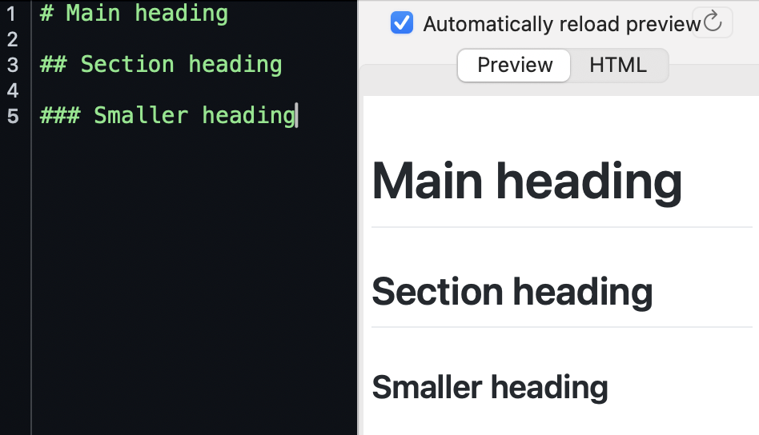

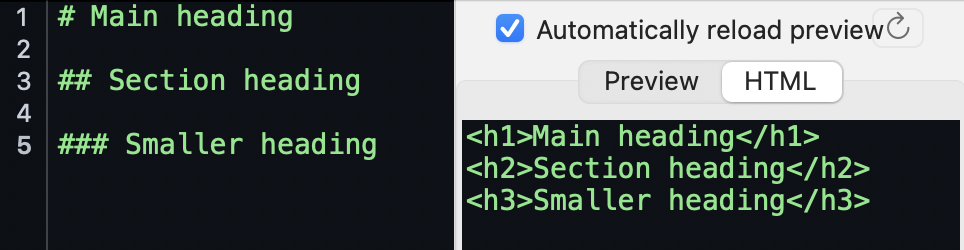

## Markdown: emphasis

### Raw Markdown

```markdown
*italics*

**boldface**

***bold italics***

`inline code like sd(data$reactionTimes`
```

### Rendered

*italics*

**boldface**

*bold italics*

`inline code`

## Markdown: bullet points

### Raw Markdown

```markdown
- First point
- Second point
  - Nested point
- Third point
```

### Rendered

- First point
- Second point
  - Nested point
- Third point

## Markdown: quotations

### Raw Markdown

```markdown
> Good communication makes
> analysis useful.
```

### Rendered

> Good communication makes analysis useful.

## Markdown: links

### Raw Markdown

```markdown
[my pres](https://patrickabolger.github.io/quartoWorkshop/){target="_blank"}
```

### Rendered

[my pres](https://patrickabolger.github.io/quartoWorkshop/)

**Note**

`{target="_blank"}` is actually specific to *Quarto Markdown*, and opens links in new tabs instead of the same tab

## Markdown: formulas (with LaTeX)<sup>1</sup>

### LaTeX in Markdown

```markdown
This is the *F*-ratio: $F=\frac{MS_{between}}{MS_{within}}$

And in a little more detail:
$$
F=\frac{SS_{between}/df_{between}}{SS_{within}/df_{within}}
$$
```

### Rendered

This is the *F*-ratio: $F=\frac{MS_{between}}{MS_{within}}$

And in a little more detail:
$$F=\frac{SS_{between}/df_{between}}{SS_{within}/df_{within}}$$

[^3]: Only in a few flavors of *Markdown*

## Markdown: tables<sup>1</sup>

### raw Markdown

```markdown
| Tables   |      Are      |  Cool |
|----------|:-------------:|------:|
| col 1 is |  left-aligned | $1600 |
| col 2 is |    centered   |   $12 |
| col 3 is | right-aligned |    $1 |
```

### Rendered

| Tables | Are | Cool |
| --- | --- | --- |
| col 1 is | left-aligned | $1600 |
| col 2 is | centered | $12 |
| col 3 is | right-aligned | $1 |

[^4]: example from https://www.tablesgenerator.com/

# Quarto file structure

## Anatomy of a `.qmd` file<sup>1</sup>

```markdown
---
title: "My report"
format: html
---

<!-- above is the YAML header -->

# Introduction

This is the **Markdown area**.

<!-- below is a code chunk -->

``{r}
summary(mtcars)
``
```

**Note**

The code chunk should actually have 3 backticks, closed by 3 backticks as well. If I put 3 in for this demo, weird things happen. Also note that `<!-- this is an unintepreted comment in the markdown area -->`, whereas `# this is an uninterpreted R comment in an R script or code chunk (in Quarto)`.

[^5]: `.Rmd` files differ in only minor ways

## 1. YAML header

```yaml
---
title: "Student wellbeing summary"
author: "Patrick Bolger"
date: today
format:
  html:
    toc: true
---
```

- Located at the very top of the file
- Begins and ends with `---`
- Stores document metadata and output settings
- Indentation matters (as in Python)

## 2. Markdown area

```markdown
# Introduction

This report summarises a small survey.

## Key findings

- Most respondents reported...
- The clearest pattern was...
```

- Prose and structure
- Images, simple tables, links, and citations
- Readable before rendering

## 3. Code blocks

````markdown
```{r}
#| eval: false
#| label: fig-scatter
#| fig-cap: "Miles per gallon by weight"

plot(mtcars$wt, mtcars$mpg)
```
````

- Fenced by three backticks
- `{r}` identifies the language<sup>1</sup>
- `#|` lines are chunk options<sup>2</sup>
- Output appears in the rendered document
[^6]: This would be `{python}`, `{julia}`, and `{ojs}` for *python*, *julia*, and *Observable JS*, respectively
[^7]: The `eval: false` in the chunk options (`#|`) at top tells *R* not to run the code in that chunk. You wouldn’t normally include this option in a finished product unless you were teaching.

## One source, different outputs

Change the YAML rather than rewriting the content

```yaml
title: "How to use Quarto"
author: "Patrick Bolger"
date: today
format: html
```

```yaml
title: "How to use Quarto"
author: "Patrick Bolger"
date: today
format:
  docx: default
  typst: default
```

```yaml
title: "How to use Quarto"
author: "Patrick Bolger"
date: today
format:
  revealjs: default
  pptx: default
```

**Warning**

Not every design feature transfers perfectly between formats. Render early and inspect the result.

**Note**

Rendering to `.pdf` requires that you have some version of *LaTeX* installed. The easiest way to do this is to install the *R* package *tinytex*, which installs a minimal version of *LaTeX*. *Typst* gets around this, but is still in development.

When you have multiple output formats, click `Render` at the top and choose the output from the drop-down menu

# Practice

## Part 1: Pick 1 or 2 output types

### non-pdfs

- `output: html`
  - webpage
- `output: revealjs`
  - html slide deck
- `output: docx`
  - MS *Word*
- `output: pptx`
  - MS *PowerPoint*

### `output: pdf` (more difficult pdfs)

- this traditionally required installing *LaTeX*
- easiest to use the *tinytex* package in *R*
- but not today, unless you already have *LaTeX* installed

### `output: typst` (easier pdfs)

- *Quarto* can use *Typst* now
- *Typst* comes built in to *Quarto*
- New and under development

**Tip**

If you choose 2 output types, make them the same type of document (e.g., `docx` and `typst`, or `revealjs` and `pptx`). This minimises incompatibility issues.

## Part 2: Choose a small, familiar topic

This could be anything in or out of psychology

## Part 3: Create a project in *RStudio*

- `File > New Project`
- `File > New File > Quarto Document` (or `Quarto Presentation`)
  - This distinctions are just for initial convenience
  - The `output:` line in the YAML header determines the document output

# Use *MS Copilot* to get started

## Part 4: Build the prompt from four parts

1. **Goal**: what should Copilot create?
2. **Context**: audience and purpose
3. **Source**: content, data or code to use
4. **Expectations**: exact format and constraints

### Aim for:

- A title and format (YAML header)
- Two or three sections (Markdown)
- One short *R* code block (code chunk)

**Tip**

Ask for the complete `.qmd` source in **one fenced code block**, with no missing sections and no invented data.

## Copilot prompt template

> Create a minimal Quarto document for [AUDIENCE] about [TOPIC]. It will be edited and rendered in RStudio.

> Output format: [html / docx / pdf / revealjs]. Include: [TITLE], [2–3 SECTIONS], and one short R code block that uses [BUILT-IN DATA / CODE I PROVIDE].

> Requirements:
> - Return the complete contents of one .qmd file.
> - Put the entire file in one fenced code block.
> - Include a valid YAML header.
> - Use simple Markdown.
> - Use only packages and data named in this prompt.
> - Do not invent results or references.
> - Keep it short enough to inspect line by line.
> - After the code block, give a three-item render checklist.

## Example student prompt

> Create a minimal Quarto HTML document for first-year psychology students about the relationship between sleep and concentration. It will be edited and rendered in RStudio.

> Include a title, a short introduction, two sections, and one *R* code block using only the built-in *mtcars* data to demonstrate a scatterplot. Explain clearly that the dataset is only a coding demonstration and is not evidence about sleep or concentration.

> Return one complete `.qmd` file in one fenced code block. Include a valid YAML header with a table of contents. Use simple Markdown. Do not invent results, sources or packages. Finish with a three-item render checklist.

## Part 5: From *Copilot* to *Quarto*

1. Inspect the response for invented claims or unnecessary packages
2. Copy only the contents inside the code fence (*see warning below*)
3. In your default `.qmd`, delete all the starter text and save, typing in a reasonable file name
4. Paste the contents from the code fence in *Copilot*
5. Save again
6. Select **Render**
7. If there are errors, read them carefully, revise, and render again

**Warning**

Use the copy icon. Don’t use the mouse. If you do, you’ll get all the line numbers, which will mess things up.

## Part 6: Debugging prompts (1)

If rendering fails, paste the **exact error** into Copilot:

> This Quarto document fails to render. Explain the error in plain English, then return the smallest corrected version. Do not add new packages or features.

> [PASTE ERROR]

> [UPLOAD `.QMD`]

## Part 6: Debugging prompts (2)

If rendering works but looks poor:

> Keep the content and output format unchanged. Improve only the headings, spacing and chunk options. Return the complete revised `.qmd` file.

## Before you finish, check for the following

### These are common AI issues

- Valid YAML header
- Closing backticks present
- Required packages installed
- Data actually available
- Output renders
- Claims checked by you<sup>1</sup>
- File names sensible
[^8]: Copilot can draft the source. But naturally, *you* are responsible for the content, code, evidence and final output.

# Summary

## *Quarto* turns a readable source file into professional communication.

- *Markdown* provides structure
- YAML controls the output
- Code blocks make results reproducible
- *MS Copilot* can accelerate a minimal first draft
- Rendering and checking remain human tasks

# Links

## Possible outputs

- [*Pandoc*](https://pandoc.org/)<sup>1</sup>
- [full list for *R Markdown*](https://rmarkdown.rstudio.com/formats.html)
- [full list for *Quarto*](https://quarto.org/docs/output-formats/all-formats.html)
[^9]: *Pandoc* what converts *Markdown* to various formats

## Webpages and books

### Webpages

- [R Markdown](https://rmarkdown.rstudio.com/)
- [Quarto](https://quarto.org/)
- [tinytex (to render to pdf)](https://yihui.org/tinytex/)
- [Typst](https://typst.app/)

### IDEs (Integrated Development Environment)

- [RStudio](https://posit.co/products/open-source/rstudio)
- [Positron](https://positron.posit.co/)
  - The company *Posit* is slowly moving away from *RStudio* and towards *Positron*, just as it’s moving away from *R Markdown* and towards *Quarto*

## LinkedIn Learning (where you can earn badges to put on your CV)

- Complete Guide to R: Wrangling, Visualizing, and Modeling Data (R Basics)
- Learning the R Tidyverse
- Learning Markdown: Formatting Text without the Complexity
- Git Essential Training<sup>1</sup>

Nothing on *R* in *Quarto* yet; just a course on using *Python* in *quarto*

[^10]: [*Git*](https://git-scm.com/) is a [distributed version-control system](https://en.wikipedia.org/wiki/Distributed_version_control). Combined with [*GitHub*](https://github.com/), it functions like *Dropbox*, but with each step of the process explicitly controlled by each collaborator.

## More LinkedIn Learning

### These are focused on the 3 programming languages besides *R* available in *Quarto*

- The *Python* programming language
- The *Julia* programming language
- *Observable*<sup>1</sup>
[^11]: *Observable* is the platform; *Observable JS* is the reactive JavaScript environment it uses. The *LinkedIn Learning* course is therefore relevant to *Quarto*’s `{ojs}` code blocks, although it may also cover features specific to the more general *Observable* platform.

## Tutorials from *Posit*

### Specific

- [*R Markdown*](https://rmarkdown.rstudio.com/lesson-1.html)
- [*Quarto*](https://quarto.org/docs/get-started/hello/rstudio.html)

### General

[*Posit Academy*](https://academy.posit.co/)

## Books

- [*R Markdown: The definitive guide*](https://pkg.yihui.org/rmarkdown-book/)
- [*bookdown: Authoring Books and Technical Documents with R Markdown*](https://pkg.yihui.org/bookdown/)
- [*R for Data Science*, 2nd ed.](https://r4ds.hadley.nz/)<sup>1</sup>
[^12]: This is not a book *on* *Quarto*, but rather an important, general book on *R* written *in* *Quarto*. That said, the last chapter is about *Quarto*. I can’t find any books devoted to teaching *Quarto* yet.

## Galleries (examples of output)

### From *Posit*

- [Gallery for *Quarto*](https://quarto.org/docs/gallery/)
- [Gallery for *R Markdown*](https://rmarkdown.rstudio.com/gallery.html)
  - [Main gallery for *Bookdown*](https://bookdown.org/)
  - [Archive for *Bookdown*](https://bookdown.org/archive/)<sup>1</sup>

### From me

- [A statistics lab manual](https://patrickabolger.github.io/ElemStatsLabManual/) I wrote at Texas A&M
- [An EDI project](https://psychopy.github.io/psychopy-edi-survey/) I worked on at *PsychoPy*/*Open Science Tools* at in *Psychology* at the *University of Nottingham*
[^13]: Note that the *Bookdown* hosting service will be [fully decommisioned](https://posit.co/blog/bookdown-org-sunset) on 31 January 2027. Books will mostly migrate over to [*Posit Connect*](https://posit.co/products/enterprise/connect)